# Unit 2

### 1) **System Development Life Cycle (SDLC)**

**Definition**: SDLC is a conceptual model that includes policies and procedures for developing or modifying systems through their life cycle. It aims to create high-quality systems that meet customer expectations, stay within budget and schedule, and function effectively.

#### **Phases of SDLC**:

1. **Feasibility Study/Planning**:
   - Define the problem and objectives.
   - Determine feasibility and prepare a project schedule.
   - Address security, integration, and constraints.
2. **Analysis and Specification**:
   - Gather, analyze, and validate information.
   - Define requirements and create prototypes.
   - Develop the Software Requirement Specification (SRS).
3. **System Design**:
   - Plan databases, interfaces, and networks.
   - Convert SRS into a logical structure.
   - Prepare a detailed design document.
4. **Implementation**:
   - Code and combine modules.
   - Perform error detection in a training environment.
   - Integrate and install the system.
5. **Testing**:
   - Validate the system against requirements.
   - Conduct unit, integration, system, and acceptance testing.
6. **Deployment**:
   - Certify and release the software.
   - Begin maintenance once deployed.
7. **Maintenance/Support**:
   - Address on-site or remote support needs.
   - Implement updates and accommodate new requirements.

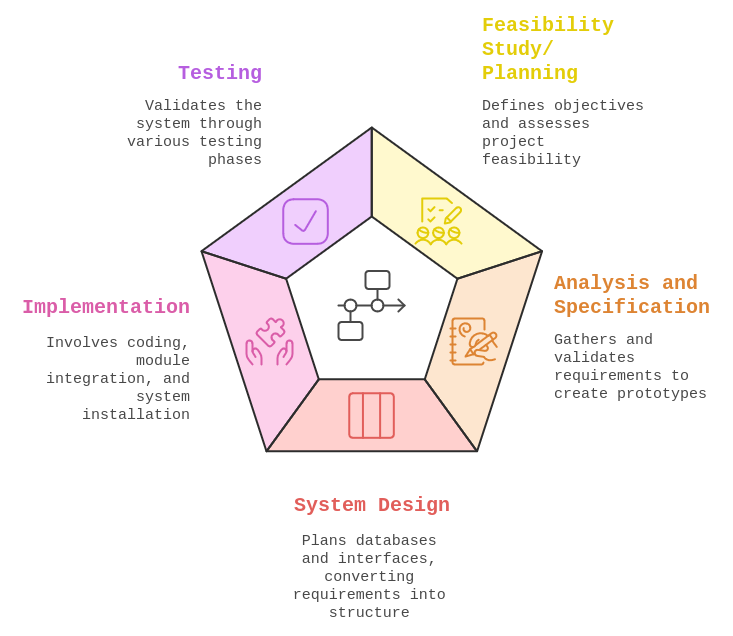

### 2) **Information Gathering Techniques**

#### **Purpose**:

To determine organizational information requirements and prepare a precise SRS.

#### **Techniques**:

1. **Interviewing**:
   - Conduct structured (predefined questions) or unstructured (open-ended) interviews.
   - Benefits: Facilitates understanding, discovers key problems, and bridges communication gaps.
2. **Questionnaires**:
   - Free-format: Open-ended responses.
   - Fixed-format: Close-ended, rating, or ranking questions.
   - Benefits: Handles large groups, ensures confidentiality, and gathers factual data.
3. **Review of Records, Procedures, and Forms**:
   - Analyze existing documentation to understand current system capabilities and workflows.
4. **Observation**:
   - Directly observe workflows and user interactions to collect accurate data.
5. **Modern Methods**:
   - **Joint Application Development (JAD)**: Collaborative workshops with users, analysts, and developers.
   - **Prototyping**: Build and adjust working prototypes based on user feedback.
   - **Group Support Systems (GSS)**: Tools for team collaboration and decision-making.
   - **CASE Tools**: Computer-aided software engineering tools to enhance quality.

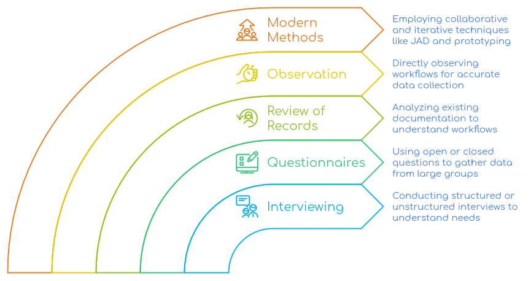

### 3) **Software Requirements Specification (SRS)**

#### **Definition**:

SRS is a written description of the software system’s requirements. It serves as a blueprint for design, development, and validation.

#### **Goals**:

1. **Customer Feedback**: Ensures the development team understands the client’s needs.
2. **Break Down Requirements**: Organizes and structures information logically.
3. **Facilitate Documentation**: Provides a basis for design and validation.
4. **Product Validation**: Guides testing to meet requirements.

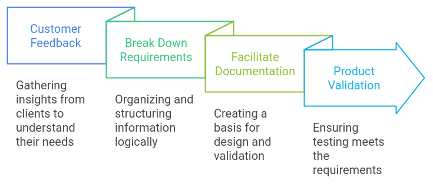

#### **SRS Format**:

1. **General Description**:
   - Objective, user characteristics, and key features.
2. **Functional Requirements**:
   - Describes desired system behavior and expected outputs.
3. **Interface Requirements**:
   - Defines communication protocols, data sharing, and user interaction.
4. **Performance Requirements**:
   - Specifies constraints like speed, memory usage, and error rates.
5. **Non-Functional Attributes**:
   - Includes attributes like security, portability, reliability, and scalability.
6. **Preliminary Schedule and Budget**:
   - Outlines initial timeline and costs.

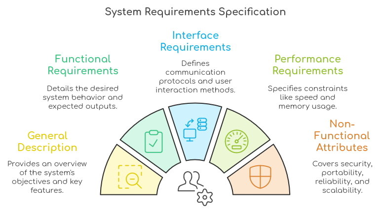